# Teso trial - land size checks

# 9 GPS of plot type

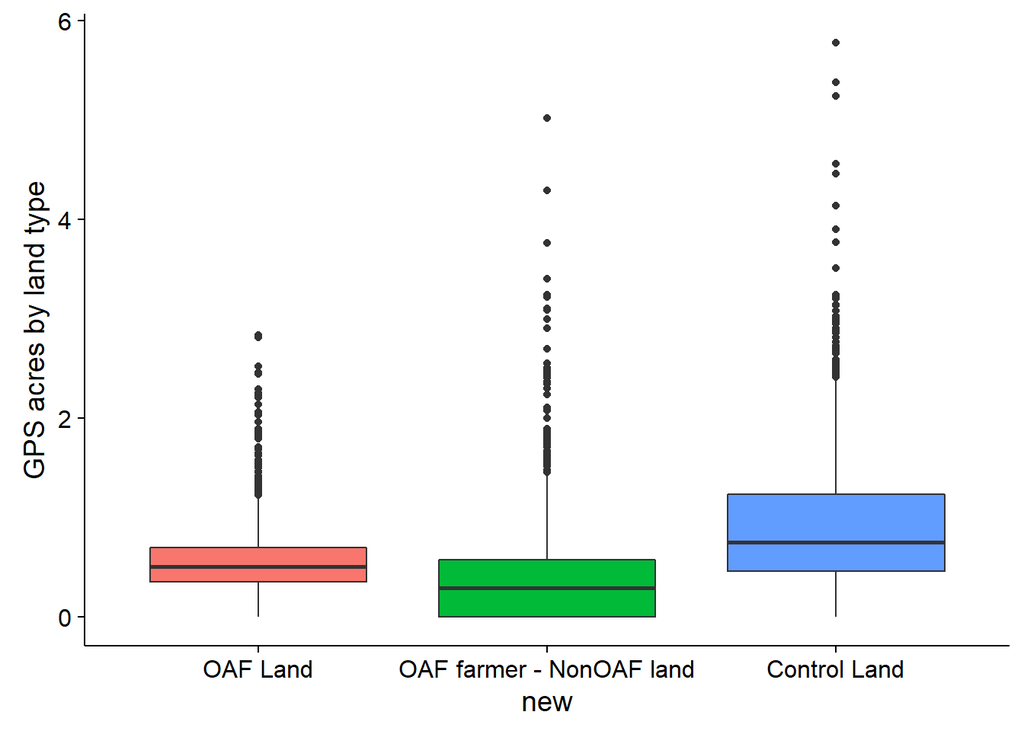

```r
oafland <- subset(dat, is.na(total_OAF_maize_GPSacres) == FALSE)

# summary(dat$total_OAF_maize_GPSacres)

T_nonoaf_land <- subset(dat, is.na(total_nonOAF_maize_GPSacres) == FALSE & PC_Flag ==
    "T")
C_nonoaf_land <- subset(dat, is.na(total_nonOAF_maize_GPSacres) == FALSE & PC_Flag ==
    "C")

# table(dat$total_OAF_maize_GPSacres)

oafland$new = "OAF Land"
T_nonoaf_land$new = "OAF farmer - NonOAF land"
C_nonoaf_land$new = "Control Land"


gpsland = rbind(data.frame(new = oafland$new, ACRES = oafland$total_OAF_maize_GPSacres),
    data.frame(new = T_nonoaf_land$new, ACRES = T_nonoaf_land$total_nonOAF_maize_GPSacres),
    data.frame(new = C_nonoaf_land$new, ACRES = C_nonoaf_land$total_nonOAF_maize_GPSacres))

gt <- merge(oafland, T_nonoaf_land, by = "unique_id", all = TRUE)


gt$test <- rowSums(gt[, c("total_OAF_maize_GPSacres.x", "total_nonOAF_maize_GPSacres.y")],
    na.rm = TRUE)

# mean(gt$test, na.rm=TRUE)

ggplot(gpsland, aes(x = new, y = ACRES, fill = new)) + geom_boxplot() + guides(fill = FALSE) +
    ylab("GPS acres by land type")
```

```r
tab <- data.frame(Variable = as.character("N"), `OAF Land` = NA, `OAF - NonOAF land` = NA,
    `Control land` = NA)
tab$Variable <- as.character(tab$Variable)

tab[1, ] <- c("Mean acres GPS ", mean(gpsland$ACRES[gpsland$new == "OAF Land"],
    na.rm = TRUE), mean(gpsland$ACRES[gpsland$new == "OAF farmer - NonOAF land"],
    na.rm = TRUE), mean(gpsland$ACRES[gpsland$new == "Control Land"], na.rm = TRUE))

tab[2, ] <- c("StDev acres GPS ", sd(gpsland$ACRES[gpsland$new == "OAF Land"],
    na.rm = TRUE), sd(gpsland$ACRES[gpsland$new == "OAF farmer - NonOAF land"],
    na.rm = TRUE), sd(gpsland$ACRES[gpsland$new == "Control Land"], na.rm = TRUE))

tab[3, ] <- c("N ", length(gpsland$ACRES[gpsland$new == "OAF Land"]), length(gpsland$ACRES[gpsland$new ==
    "OAF farmer - NonOAF land"]), length(gpsland$ACRES[gpsland$new == "Control Land"]))

tab[, 2] <- as.numeric(tab[, 2])
tab[, 3] <- as.numeric(tab[, 3])
tab[, 4] <- as.numeric(tab[, 4])

kable(tab, format = "markdown", align = "c", digits = 2)
```

| Variable | OAF.Land | OAF…NonOAF.land | Control.land |
| --- | --- | --- | --- |
| Mean acres GPS | 0.58 | 0.43 | 0.94 |
| StDev acres GPS | 0.37 | 0.54 | 0.71 |
| N | 1223.00 | 1223.00 | 1165.00 |

# 10 Differences between self-reporting and GPS by group

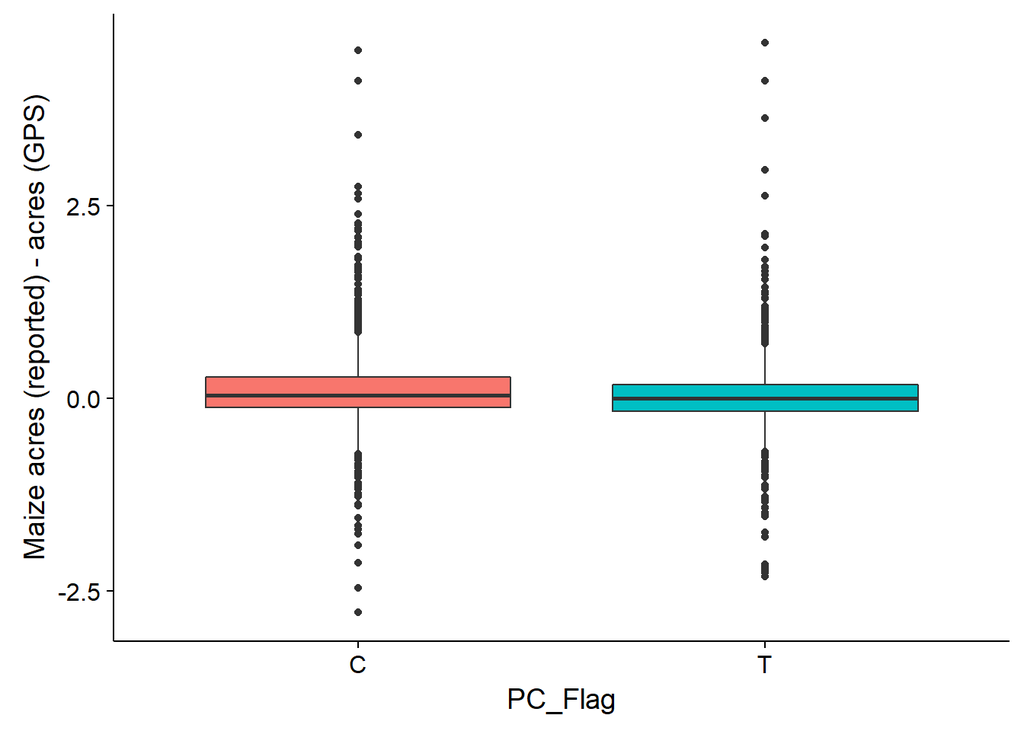

```r
dat$difference <- dat$total_acres - dat$GPS_maize_acres

ggplot(dat, aes(x = PC_Flag, y = difference, fill = PC_Flag)) + geom_boxplot() +
    guides(fill = FALSE) + ylab("Maize acres (reported) - acres (GPS)")
```

```r
tab <- data.frame(Variable = as.character("N"), Control = NA, Treated = NA)
tab$Variable <- as.character(tab$Variable)
tab[1, ] <- c("Mean difference (acres) ", mean(subset(dat, PC_Flag == "C")$difference,
    na.rm = TRUE), mean(subset(dat, PC_Flag == "T")$difference, na.rm = TRUE))
tab[2, ] <- c("StDev difference (acres) ", sd(subset(dat, PC_Flag == "C")$difference,
    na.rm = TRUE), sd(subset(dat, PC_Flag == "T")$difference, na.rm = TRUE))
tab[3, ] <- c("N", sum(!is.na(subset(dat, PC_Flag == "C")$total_acres)), sum(!is.na(subset(dat,
    PC_Flag == "T")$total_acres)))
tab[, 2] <- as.numeric(tab[, 2])
tab[, 3] <- as.numeric(tab[, 3])
kable(tab, format = "markdown", align = "c", digits = 2)
```

| Variable | Control | Treated |
| --- | --- | --- |
| Mean difference (acres) | 0.11 | 0.02 |
| StDev difference (acres) | 0.57 | 0.50 |
| N | 1165.00 | 1223.00 |

# 11 Differences between Land Estimate (LE) and Planting Compliance (PC) forms by self reporting

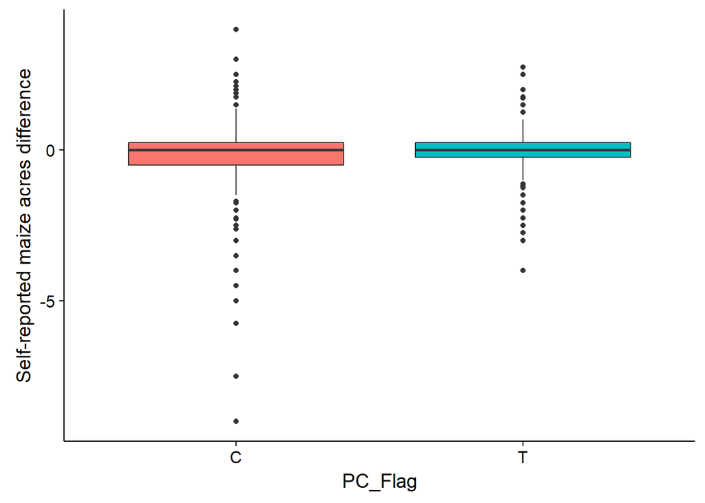

```r
# find_name(colnames(dat), 'Acres')
dat$diff_PCLE <- rowSums(dat[, c("LE_form.Land_Estimates_Survey.OAF_Maize_Acres",
    "LE_form.Land_Estimates_Survey.NonOAF_Maize_Acres")], na.rm = TRUE) - rowSums(dat[,
    c("PC_Planting_Compliance_Crop_Mix.LR_2017_Planting.Land_Planted_2017.totalacres_oafmaize",
        "PC_Planting_Compliance_Crop_Mix.LR_2017_Planting.Nonoaf_CropMix017lr.totalacres_nonoafmaize")],
    na.rm = TRUE)

# find_name(colnames(dat), 'totalacres_oafma')
ggplot(dat, aes(x = PC_Flag, y = diff_PCLE, fill = PC_Flag)) + geom_boxplot() +
    guides(fill = FALSE) + ylab("Self-reported maize acres difference")
```

```r
tab <- data.frame(Variable = as.character("N"), Control = NA, Treated = NA)
tab$Variable <- as.character(tab$Variable)
tab[1, ] <- c("Mean difference LE-PC (acres) ", mean(subset(dat, PC_Flag ==
    "C")$diff_PCLE, na.rm = TRUE), mean(subset(dat, PC_Flag == "T")$diff_PCLE,
    na.rm = TRUE))
tab[2, ] <- c("StDev difference (acres) ", sd(subset(dat, PC_Flag == "C")$diff_PCLE,
    na.rm = TRUE), sd(subset(dat, PC_Flag == "T")$diff_PCLE, na.rm = TRUE))
tab[3, ] <- c("N", sum(!is.na(subset(dat, PC_Flag == "C")$total_acres)), sum(!is.na(subset(dat,
    PC_Flag == "T")$total_acres)))
tab[, 2] <- as.numeric(tab[, 2])
tab[, 3] <- as.numeric(tab[, 3])
kable(tab, format = "markdown", align = "c", digits = 2)
```

| Variable | Control | Treated |
| --- | --- | --- |
| Mean difference LE-PC (acres) | -0.11 | -0.05 |
| StDev difference (acres) | 0.98 | 0.63 |
| N | 1165.00 | 1223.00 |

# 12 Planting compliance (PC) acreage vs. GPS acreage (GPS)

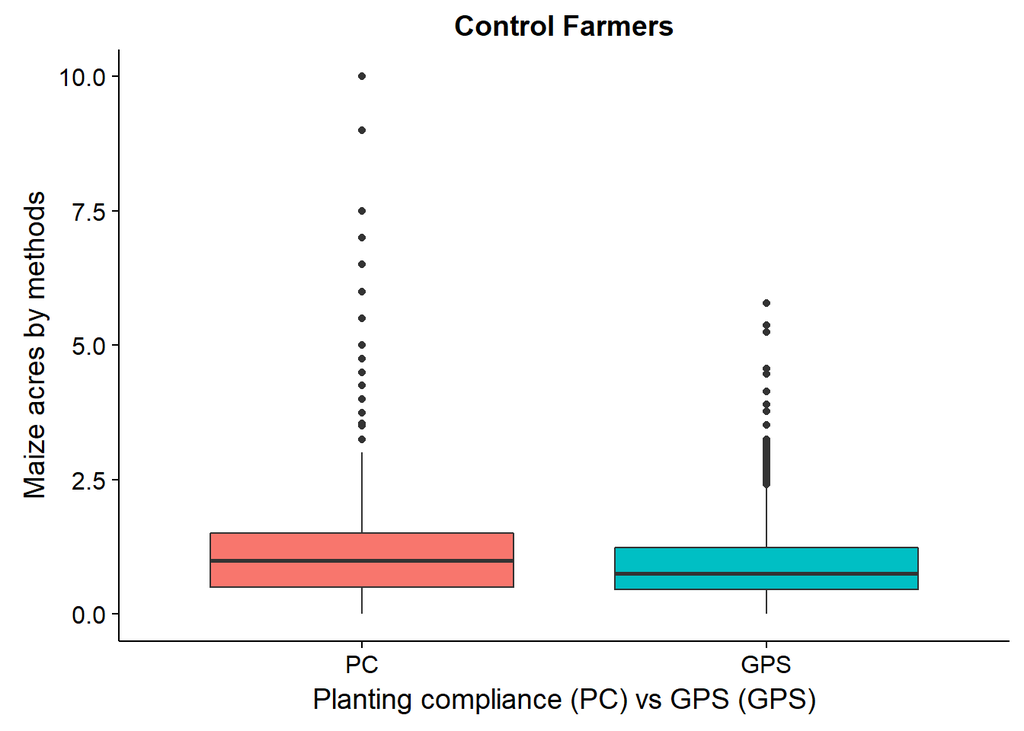

```r
# find_name(colnames(dat), 'Acres')
dat$PC_acres <- rowSums(dat[, c("PC_Planting_Compliance_Crop_Mix.LR_2017_Planting.Land_Planted_2017.totalacres_oafmaize",
    "PC_Planting_Compliance_Crop_Mix.LR_2017_Planting.Nonoaf_CropMix017lr.totalacres_nonoafmaize")],
    na.rm = TRUE)
# GPS_maize_acres
da <- data.frame(acres = dat$PC_acres, Flag = "PC", PC_Flag = dat$PC_Flag)
db <- data.frame(acres = dat$GPS_maize_acres, Flag = "GPS", PC_Flag = dat$PC_Flag)
df <- rbind(da, db)
dfC <- subset(df, PC_Flag == "C")
dfT <- subset(df, PC_Flag == "T")

ggplot(dfC, aes(x = Flag, y = acres, fill = Flag)) + geom_boxplot() + guides(fill = FALSE) +
    ylab("Maize acres by methods") + ggtitle("Control Farmers") + xlab("Planting compliance (PC) vs GPS (GPS)")
```

```r
tab <- data.frame(Variable = as.character("N"), `PC (control)` = NA, `GPS (control)` = NA)
tab$Variable <- as.character(tab$Variable)
tab[1, ] <- c("Mean acres ", mean(subset(dfC, Flag == "PC")$acres, na.rm = TRUE),
    mean(subset(dfC, Flag == "GPS")$acres, na.rm = TRUE))
tab[2, ] <- c("StDev acres ", sd(subset(dfC, Flag == "PC")$acres, na.rm = TRUE),
    sd(subset(dfC, Flag == "GPS")$acres, na.rm = TRUE))
tab[, 2] <- as.numeric(tab[, 2])
tab[, 3] <- as.numeric(tab[, 3])
kable(tab, format = "markdown", align = "c", digits = 2)
```

| Variable | PC..control. | GPS..control. |
| --- | --- | --- |
| Mean acres | 1.16 | 0.94 |
| StDev acres | 1.04 | 0.71 |

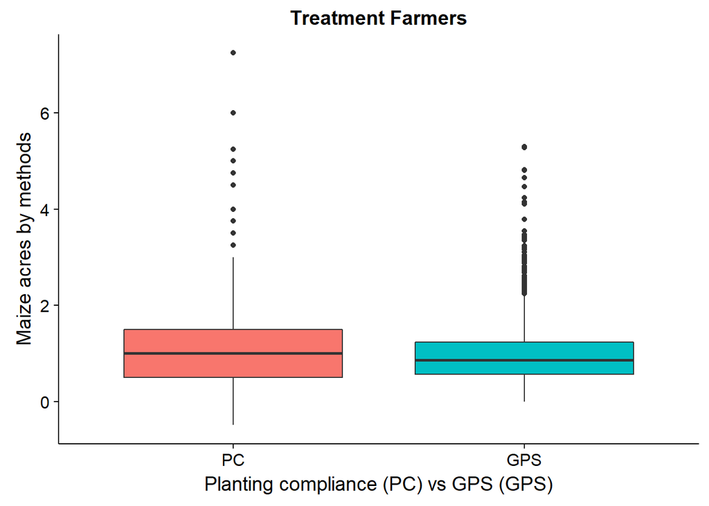

```r
ggplot(dfT, aes(x = Flag, y = acres, fill = Flag)) + geom_boxplot() + guides(fill = FALSE) +
    ylab("Maize acres by methods") + ggtitle("Treatment Farmers") + xlab("Planting compliance (PC) vs GPS (GPS)")
```

```r
tab <- data.frame(Variable = as.character("N"), `PC (Treatment)` = NA, `GPS (Treatment)` = NA)
tab$Variable <- as.character(tab$Variable)
tab[1, ] <- c("Mean acres ", mean(subset(dfT, Flag == "PC")$acres, na.rm = TRUE),
    mean(subset(dfT, Flag == "GPS")$acres, na.rm = TRUE))
tab[2, ] <- c("StDev acres ", sd(subset(dfT, Flag == "PC")$acres, na.rm = TRUE),
    sd(subset(dfT, Flag == "GPS")$acres, na.rm = TRUE))
tab[, 2] <- as.numeric(tab[, 2])
tab[, 3] <- as.numeric(tab[, 3])
kable(tab, format = "markdown", align = "c", digits = 2)
```

| Variable | PC..Treatment. | GPS..Treatment. |
| --- | --- | --- |
| Mean acres | 1.08 | 1.01 |
| StDev acres | 0.81 | 0.69 |

```r
madedat <- dat
```

```r
#vars to examine b
vars <- c("LE_form.Land_Estimates_Survey.Owned_Acres" ,"LE_form.Land_Estimates_Survey.Rented_Acres" ,"LE_form.Land_Estimates_Survey.Cultivated_Acres","LE_form.Land_Estimates_Survey.OAF_Maize_Acres","LE_form.Land_Estimates_Survey.OAF_Maize_Beans_Intercrop_Acres","LE_form.Land_Estimates_Survey.NonOAF_Maize_Acres","LE_form.Land_Estimates_Survey.NonOAF_Maize_Beans_Intercrop_Acres" )
#plots <- plot_vars(vars, dat, "LE_username",2, "./plots/", xys=c( "LE_username","LE_form.identifier.site"))
```

# 13 Fall army worm (FAW) checks

I have made a metric for FAW infestation. This metric is based on FO’s subjective assessment of the extent of the infestation.

## 13.1 Simple descriptions

> FAW intensity is on a scale from 0 to 30, with 30 being the most severe.

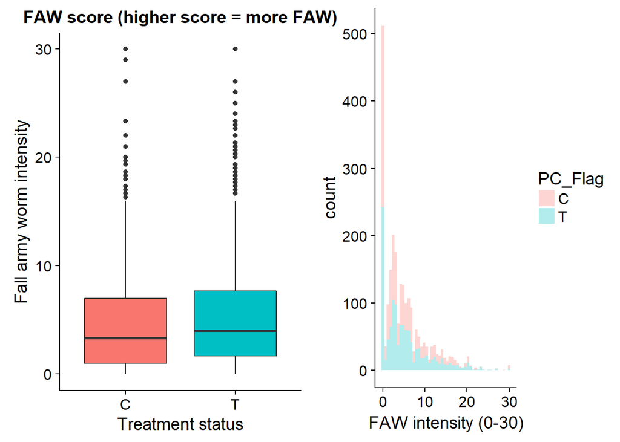

```r
g1 <- ggplot(dat, aes(x=PC_Flag, y= FAWmetric, fill=PC_Flag)) + geom_boxplot() +  guides(fill=FALSE) + ylab("Fall army worm intensity") + ggtitle("FAW score (higher score = more FAW)") + xlab("Treatment status")

g2 <- ggplot(dat, aes(x=FAWmetric, fill=PC_Flag)) + geom_histogram(alpha=.3, bins=50) + xlab("FAW intensity (0-30)")

multiplot(g1,g2, cols=2)
```

```r
tab <- data.frame("Variable" = as.character("N"),"Control" = NA, "Treated" = NA)
tab$Variable <- as.character(tab$Variable)
tab[1,] <- c("Mean FAW score ",mean(subset(dat, PC_Flag=="C")$FAWmetric, na.rm=TRUE),mean(subset(dat, PC_Flag=="T")$FAWmetric, na.rm=TRUE))
tab[2,] <- c("StDev FAW score ",sd(subset(dat, PC_Flag=="C")$FAWmetric, na.rm=TRUE),sd(subset(dat, PC_Flag=="T")$FAWmetric, na.rm=TRUE))
tab[,2] <- as.numeric(tab[,2])
tab[,3] <- as.numeric(tab[,3])
kable(tab, format="markdown", align="c", digits=2)
```

| Variable | Control | Treated |
| --- | --- | --- |
| Mean FAW score | 4.89 | 5.39 |
| StDev FAW score | 5.26 | 5.37 |

```r
d <- subset(dat, is.na(FAWmetric)==FALSE)

f <- subset(d,FAWmetric>0 )
xT <- dim(subset(f, PC_Flag=="T"))[1]
xC <- dim(subset(f, PC_Flag=="C"))[1]
```

Total number of farmers with any FAW:

- Treated farmers: 981 out of 1223 total treated farmers with data.
- Control farmers: 895 out of 1165 total control farmers with data.

# 14 Land estimate (LE) and back-check comparisons

```r
lst1 <- as.list(list.files(path="../../Data/Backchecks/LE/", pattern="*.csv*", full.names=TRUE))


d1 <- supermerge(lst1, "../../Data/Caselist PC&CM.csv")
d1$tempy <- 1
d <- clean_cc(d1, "tempy")[[1]]
d$Flag <- NULL
d1$unique_id = paste0(d1$form.oaf_id,d1$form.site  )




bac <- merge(d, madedat, by="unique_id")


bac$oaf_maize_plots <- bac$form.Back_Check.Land_Estimate.OAF_maize_plots - bac$LE_form.Land_Estimates_Survey.land_size_measurements.OAF_Maize_Plots_Num

bac$non_oaf_maize_plots <- bac$form.Back_Check.Land_Estimate.Non.OAF_maize_plots - bac$LE_form.Land_Estimates_Survey.land_size_measurements.NonOAF_Maize_Plots_Num

mean(bac$non_oaf_maize_plots, na.rm=T)

#bac[c("unique_id","non_oaf_maize_plots")]
tab1 = as.data.frame(table(bac$non_oaf_maize_plots))
colnames(tab1) = c("Difference","Freq")
```

Was able to match 222 farmers of 245 total back-checked farmers.

> Difference in number of plotsreported between first survey and back check survey, Non-OAF maize plots:

```r
kable(tab1, format = "markdown", row.names=FALSE, align='c', caption="Number of Non-OAF maize plots backchecks (0 = matching)")
```

| Difference | Freq |
| --- | --- |
| -4 | 1 |
| -3 | 2 |
| -2 | 13 |
| -1 | 45 |
| 0 | 96 |
| 1 | 39 |
| 2 | 3 |
| 3 | 2 |

> Difference in number of plots reported between first survey and back check survey, OAF maize plots:

```r
tab2 = as.data.frame(table(bac$oaf_maize_plots))
colnames(tab2) = c("Difference","Freq")
kable(tab2, format = "markdown", row.names=FALSE, align='c', caption="Number of OAF maize plots backchecks (0 = matching)")
```

| Difference | Freq |
| --- | --- |
| -2 | 1 |
| -1 | 16 |
| 0 | 78 |
| 1 | 11 |
| 2 | 2 |
| 3 | 2 |

> Plotted values: difference in number of plots between Land Estimate survey and back check

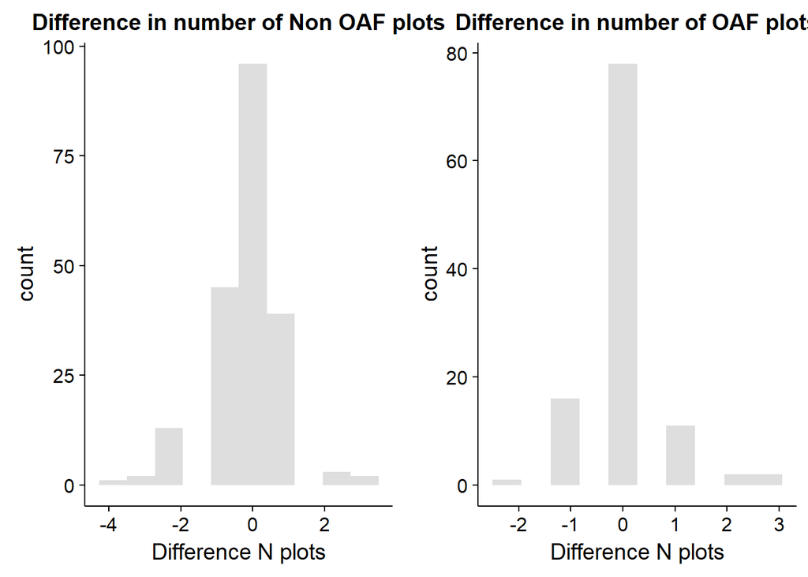

```r
p <-  ggplot(bac, aes(x=non_oaf_maize_plots) ) + geom_histogram(alpha=.2, bins=10) + ggtitle("Difference in number of Non OAF plots") + xlab("Difference N plots")

p2 <-  ggplot(bac, aes(x=oaf_maize_plots) ) + geom_histogram(alpha=.2, bins=10) + ggtitle("Difference in number of OAF plots") + xlab("Difference N plots")


multiplot(p,p2,cols = 2)
```

```r
tab <- data.frame("Variable" = as.character("N"),"OAF land" = NA, "Non OAF land" = NA)
tab$Variable <- as.character(tab$Variable)
tab[1,] <- c("Mean difference",mean(bac$oaf_maize_plots, na.rm=TRUE),mean(bac$non_oaf_maize_plots, na.rm=TRUE))
tab[2,] <- c("StDev difference",sd(bac$oaf_maize_plots, na.rm=TRUE),sd(bac$non_oaf_maize_plots, na.rm=TRUE))
tab[,2] <- as.numeric(tab[,2])
tab[,3] <- as.numeric(tab[,3])
kable(tab, format="markdown", align="c", digits=3)
```

| Variable | OAF.land | Non.OAF.land |
| --- | --- | --- |
| Mean difference | 0.027 | -0.149 |
| StDev difference | 0.723 | 0.989 |

> Difference in GPS measurements between land estimates (LE) survey and the back checks

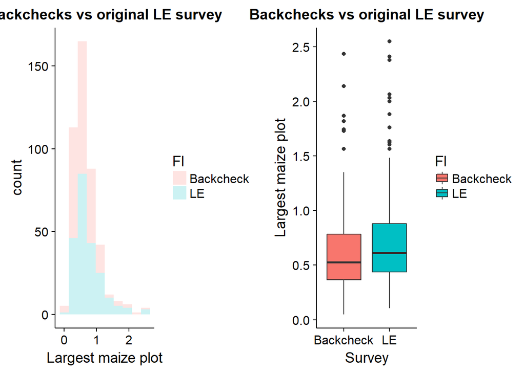

```r
bac <- as.data.frame(bac)
#add in the backcheck vars, see above for how i did this origninally
#average of OAF maize GPS

bac$plot1 <- (bac$LE_oaf_maize_plot_repeat_form.Land_Estimates_Survey.land_size_measurements.oaf_maize_plot_repeat.oaf_maize_plot.OAF_Maize_Reading_1_1 +  bac$LE_oaf_maize_plot_repeat_form.Land_Estimates_Survey.land_size_measurements.oaf_maize_plot_repeat.oaf_maize_plot.OAF_Maize_Reading_2_1 + bac$LE_oaf_maize_plot_repeat_form.Land_Estimates_Survey.land_size_measurements.oaf_maize_plot_repeat.oaf_maize_plot.OAF_Maize_Reading_3_1)/3

bac$plot2 <- (bac$LE_oaf_maize_plot_repeat_form.Land_Estimates_Survey.land_size_measurements.oaf_maize_plot_repeat.oaf_maize_plot.OAF_Maize_Reading_1_2 +  bac$LE_oaf_maize_plot_repeat_form.Land_Estimates_Survey.land_size_measurements.oaf_maize_plot_repeat.oaf_maize_plot.OAF_Maize_Reading_2_2 + bac$LE_oaf_maize_plot_repeat_form.Land_Estimates_Survey.land_size_measurements.oaf_maize_plot_repeat.oaf_maize_plot.OAF_Maize_Reading_3_2)/3

bac$plot3 <- (bac$LE_oaf_maize_plot_repeat_form.Land_Estimates_Survey.land_size_measurements.oaf_maize_plot_repeat.oaf_maize_plot.OAF_Maize_Reading_1_3 +  bac$LE_oaf_maize_plot_repeat_form.Land_Estimates_Survey.land_size_measurements.oaf_maize_plot_repeat.oaf_maize_plot.OAF_Maize_Reading_2_3 + bac$LE_oaf_maize_plot_repeat_form.Land_Estimates_Survey.land_size_measurements.oaf_maize_plot_repeat.oaf_maize_plot.OAF_Maize_Reading_3_3)/3

bac$plot4 <- (bac$LE_oaf_maize_plot_repeat_form.Land_Estimates_Survey.land_size_measurements.oaf_maize_plot_repeat.oaf_maize_plot.OAF_Maize_Reading_1_4 +  bac$LE_oaf_maize_plot_repeat_form.Land_Estimates_Survey.land_size_measurements.oaf_maize_plot_repeat.oaf_maize_plot.OAF_Maize_Reading_2_4 + bac$LE_oaf_maize_plot_repeat_form.Land_Estimates_Survey.land_size_measurements.oaf_maize_plot_repeat.oaf_maize_plot.OAF_Maize_Reading_3_4)/3

#nonoaf

bac$nonplot1 <- (bac$LE_nonoaf_maize_plot_form.Land_Estimates_Survey.land_size_measurements.nonoaf_maize_plot.nonoaf_maize_plot.nonOAF_Maize_Reading_1_1 +  bac$LE_nonoaf_maize_plot_form.Land_Estimates_Survey.land_size_measurements.nonoaf_maize_plot.nonoaf_maize_plot.nonOAF_Maize_Reading_2_1 + bac$LE_nonoaf_maize_plot_form.Land_Estimates_Survey.land_size_measurements.nonoaf_maize_plot.nonoaf_maize_plot.nonOAF_Maize_Reading_3_1)/3

bac$nonplot2 <- (bac$LE_nonoaf_maize_plot_form.Land_Estimates_Survey.land_size_measurements.nonoaf_maize_plot.nonoaf_maize_plot.nonOAF_Maize_Reading_1_2 +  bac$LE_nonoaf_maize_plot_form.Land_Estimates_Survey.land_size_measurements.nonoaf_maize_plot.nonoaf_maize_plot.nonOAF_Maize_Reading_2_2 + bac$LE_nonoaf_maize_plot_form.Land_Estimates_Survey.land_size_measurements.nonoaf_maize_plot.nonoaf_maize_plot.nonOAF_Maize_Reading_3_2)/3

bac$nonplot3 <- (bac$LE_nonoaf_maize_plot_form.Land_Estimates_Survey.land_size_measurements.nonoaf_maize_plot.nonoaf_maize_plot.nonOAF_Maize_Reading_1_3 +  bac$LE_nonoaf_maize_plot_form.Land_Estimates_Survey.land_size_measurements.nonoaf_maize_plot.nonoaf_maize_plot.nonOAF_Maize_Reading_2_3 + bac$LE_nonoaf_maize_plot_form.Land_Estimates_Survey.land_size_measurements.nonoaf_maize_plot.nonoaf_maize_plot.nonOAF_Maize_Reading_3_3)/3

bac$nonplot4 <- (bac$LE_nonoaf_maize_plot_form.Land_Estimates_Survey.land_size_measurements.nonoaf_maize_plot.nonoaf_maize_plot.nonOAF_Maize_Reading_1_4 +  bac$LE_nonoaf_maize_plot_form.Land_Estimates_Survey.land_size_measurements.nonoaf_maize_plot.nonoaf_maize_plot.nonOAF_Maize_Reading_2_4 + bac$LE_nonoaf_maize_plot_form.Land_Estimates_Survey.land_size_measurements.nonoaf_maize_plot.nonoaf_maize_plot.nonOAF_Maize_Reading_3_4)/3

bac$nonplot5 <- (bac$LE_nonoaf_maize_plot_form.Land_Estimates_Survey.land_size_measurements.nonoaf_maize_plot.nonoaf_maize_plot.nonOAF_Maize_Reading_1_5 +  bac$LE_nonoaf_maize_plot_form.Land_Estimates_Survey.land_size_measurements.nonoaf_maize_plot.nonoaf_maize_plot.nonOAF_Maize_Reading_2_5 + bac$LE_nonoaf_maize_plot_form.Land_Estimates_Survey.land_size_measurements.nonoaf_maize_plot.nonoaf_maize_plot.nonOAF_Maize_Reading_3_5)/3

#examine
#sd(bac[,c("LE_nonoaf_maize_plot_form.Land_Estimates_Survey.land_size_measurements.nonoaf_maize_plot.nonoaf_maize_plot.nonOAF_Maize_Reading_1_1","LE_nonoaf_maize_plot_form.Land_Estimates_Survey.land_size_measurements.nonoaf_maize_plot.nonoaf_maize_plot.nonOAF_Maize_Reading_2_1", "LE_nonoaf_maize_plot_form.Land_Estimates_Survey.land_size_measurements.nonoaf_maize_plot.nonoaf_maize_plot.nonOAF_Maize_Reading_3_1")])

bac$sd_test <- apply(bac[,c("LE_nonoaf_maize_plot_form.Land_Estimates_Survey.land_size_measurements.nonoaf_maize_plot.nonoaf_maize_plot.nonOAF_Maize_Reading_1_1","LE_nonoaf_maize_plot_form.Land_Estimates_Survey.land_size_measurements.nonoaf_maize_plot.nonoaf_maize_plot.nonOAF_Maize_Reading_2_1", "LE_nonoaf_maize_plot_form.Land_Estimates_Survey.land_size_measurements.nonoaf_maize_plot.nonoaf_maize_plot.nonOAF_Maize_Reading_3_1")], 1, sd, na.rm=TRUE)




# MAX of ANY plot, regardless OAF or non oaf
bac$max_maize_plot <- apply(bac[,c("plot1","plot2","plot3","plot4","nonplot1","nonplot2","nonplot3","nonplot4","nonplot5")], 1, max, na.rm=TRUE)
bac$max_maize_plot <- as.numeric(bac$max_maize_plot) * 2.47

#Now get backchecked

x1 <- find_name(colnames(bac), "Area_hectares_largest_plot")

bac$back_largest_plot <- apply(bac[,x1], 1, mean,na.rm=TRUE) *2.47

newdf <-  rbind(data.frame(plot_size=bac$back_largest_plot, Fl = "Backcheck") , data.frame(plot_size=bac$max_maize_plot, Fl = "LE") )

p <-  ggplot(newdf, aes(x=plot_size, fill=Fl) ) + geom_histogram(alpha=.2, bins=10) + ggtitle("Backchecks vs original LE survey") + xlab("Largest maize plot")

q <- ggplot(newdf, aes(x=Fl, y=plot_size, fill=Fl)) + geom_boxplot() + ggtitle("Backchecks vs original LE survey") + ylab("Largest maize plot") + xlab("Survey")


multiplot(p,q,cols = 2)
```

# 15 Rough estimates of beans acres

This obviously means we cannot be sure of the quality of these estimates. Additionally, we know from the PC survey that control farmers are more likely to overestimate their land sizes than control farmers, suggesting that our estimate here will also be biased.

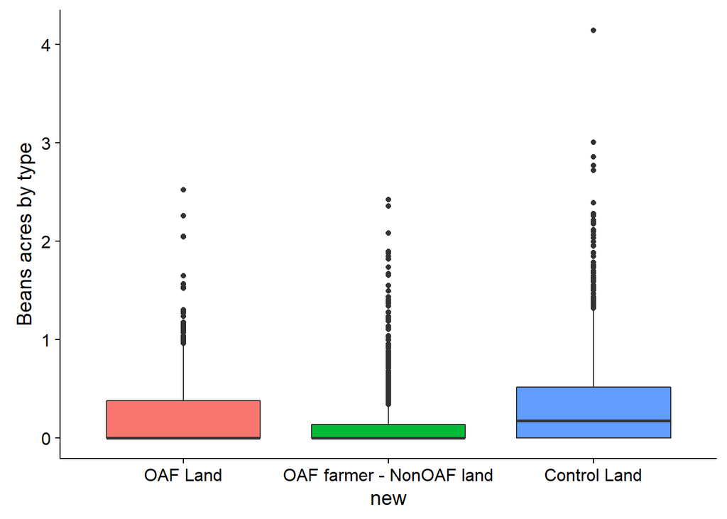

```r
dat$OAF_beans_frac <- dat$LE_form.Land_Estimates_Survey.OAF_Maize_Beans_Intercrop_Acres / dat$LE_form.Land_Estimates_Survey.OAF_Maize_Acres

dat$nonOAF_beans_frac <- dat$LE_form.Land_Estimates_Survey.NonOAF_Maize_Beans_Intercrop_Acres / dat$LE_form.Land_Estimates_Survey.NonOAF_Maize_Acres


dat$OAFbeans_acres <- dat$OAF_beans_frac * dat$total_OAF_maize_GPSacres
dat$nonOAFbeans_acres <- dat$nonOAF_beans_frac * dat$total_nonOAF_maize_GPSacres

dat$OAFbeans_acres[is.na(dat$OAFbeans_acres)]<-0
dat$nonOAFbeans_acres[is.na(dat$nonOAFbeans_acres)] <- 0




Treat <- subset(dat, PC_Flag=="T")
con <-  subset(dat, PC_Flag=="C")

TC <- Treat


Treat$new = "OAF Land"
TC$new = "OAF farmer - NonOAF land"
con$new = "Control Land"


#mean(oafland$LE_form.Land_Estimates_Survey.Remote_Acreage_OAF_maize, na.rm=TRUE)

gpsland = rbind(data.frame("new"=Treat$new, "ACRES"=Treat$OAFbeans_acres ),data.frame("new"=TC$new, "ACRES"=TC$nonOAFbeans_acres ),data.frame("new"=con$new, "ACRES"=con$nonOAFbeans_acres ))

#  mean(gt$test, na.rm=TRUE)


ggplot(gpsland, aes(x=new, y=ACRES, fill=new)) + geom_boxplot() + guides(fill=FALSE) + ylab("Beans acres by type")
```

```r
tab <- data.frame("Variable" = as.character("N"),"OAF-land" = NA, "OAF-control-land" = NA,  "Con-land"=NA)
tab$Variable <- as.character(tab$Variable)

tab[1,] <- c("Mean beans acres",mean(dat$OAFbeans_acres, na.rm=TRUE),mean(dat$nonOAFbeans_acres[dat$PC_Flag=="T"], na.rm=TRUE),mean(dat$nonOAFbeans_acres[dat$PC_Flag=="C"], na.rm=TRUE))

tab[2,] <- c("SD beans acres",sd(dat$OAFbeans_acres, na.rm=TRUE),sd(dat$nonOAFbeans_acres[dat$PC_Flag=="T"], na.rm=TRUE),sd(dat$nonOAFbeans_acres[dat$PC_Flag=="C"], na.rm=TRUE))

tab[3,] <- c("N",sum(!is.na(dat$OAFbeans_acres[dat$PC_Flag=="T"])),sum(!is.na(dat$nonOAFbeans_acres[dat$PC_Flag=="T"])),sum(!is.na(dat$nonOAFbeans_acres[dat$PC_Flag=="C"])) )
tab[,2] <- as.numeric(tab[,2])
tab[,3] <-  as.numeric(tab[,3])
tab[,4] <-  as.numeric(tab[,4])

kable(tab, format="markdown", align="c", digits=2)
```

| Variable | OAF.land | OAF.control.land | Con.land |
| --- | --- | --- | --- |
| Mean beans acres | 0.11 | 0.14 | 0.34 |
| SD beans acres | 0.25 | 0.30 | 0.48 |
| N | 1223.00 | 1223.00 | 1165.00 |

# 16 Land size estimates - Non pre exposed

Where column “not pre exposed” ==1.

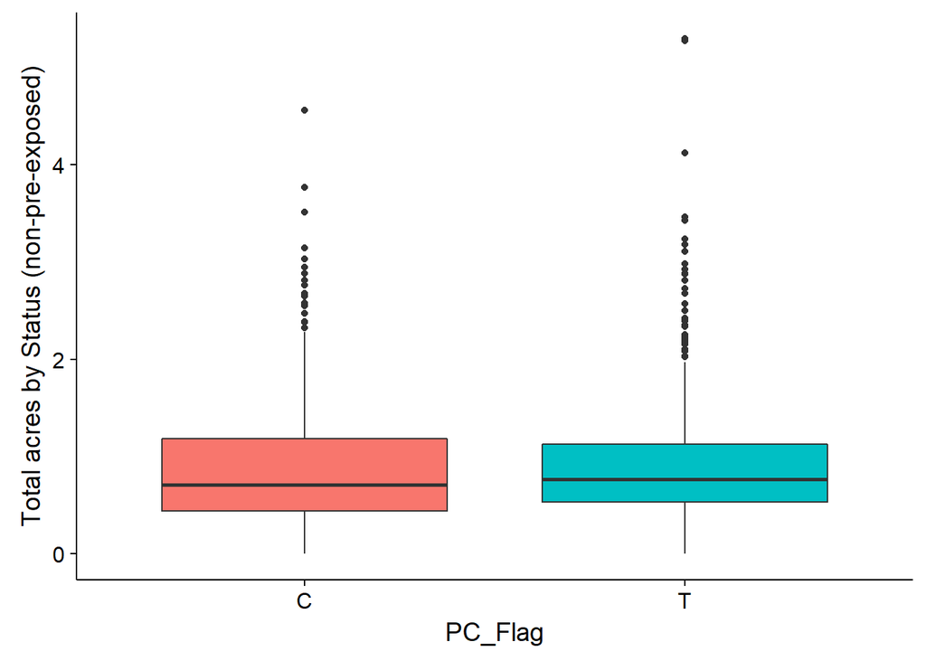

```r
rin <- read.csv("C:/Users/micha/Google Drive/One Acre Fund/MB/Gdrive-projects/Teso/Reports/all_merge/Merged_all/Cleaned Files/FAW_BH_LE.csv")

tin <- read.csv("C:/Users/micha/Google Drive/One Acre Fund/MB/Gdrive-projects/Teso/Reports/all_merge/Merged_all/Cleaned Files/baseline_cleaned.csv")

tin$unique_id <- paste0(tin$oafid, tin$site)

xdat <- merge(rin, tin, by = "unique_id")

# Not_Pre_Exposed

dat <- subset(xdat, Not_Pre_Exposed ==1)


ggplot(dat, aes(x=PC_Flag, y=total_all_land, fill=PC_Flag)) + geom_boxplot() + guides(fill=FALSE) + ylab("Total acres by Status (non-pre-exposed)")
```

```r
tab <- data.frame("Variable" = as.character("N"),"OAF" = NA, "Control"=NA)
tab$Variable <- as.character(tab$Variable)

tab[1,] <- c("Mean acres  ",mean( dat$total_all_land[dat$PC_Flag=="T"] ,na.rm=TRUE), mean(dat$total_all_land[dat$PC_Flag=="C"] , na.rm=TRUE))

tab[2,] <- c("SD acres  ",sd( dat$total_all_land[dat$PC_Flag=="T"] ,na.rm=TRUE), sd(dat$total_all_land[dat$PC_Flag=="C"] , na.rm=TRUE))

tab[,2] <- as.numeric(tab[,2])
tab[,3] <-  as.numeric(tab[,3])
#tab[,4] <-  as.numeric(tab[,4])

kable(tab, format="markdown", align="c", digits=2)
```

| Variable | OAF | Control |
| --- | --- | --- |
| Mean acres | 0.95 | 0.91 |
| SD acres | 0.70 | 0.67 |

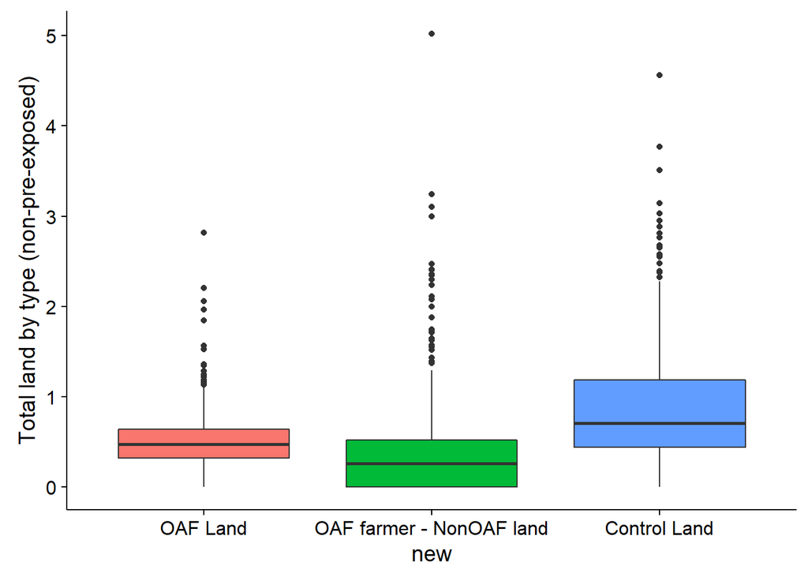

```r
# total_nonOAF_land
# total_OAF_land


oafland <- subset(dat, PC_Flag=="T")

#summary(dat$total_OAF_maize_GPSacres)

T_nonoaf_land <- subset(dat,  PC_Flag=="T")
C_nonoaf_land <- subset(dat,   PC_Flag=="C")

#table(dat$total_OAF_maize_GPSacres)

oafland$new = "OAF Land"
T_nonoaf_land$new = "OAF farmer - NonOAF land"
C_nonoaf_land$new = "Control Land"


gpsland = rbind(data.frame("new"=oafland$new, "ACRES"=oafland$total_OAF_land ),data.frame("new"=T_nonoaf_land$new, "ACRES"=T_nonoaf_land$total_nonOAF_land ),data.frame("new"=C_nonoaf_land$new, "ACRES"=C_nonoaf_land$total_nonOAF_land ))

ggplot(gpsland, aes(x=new, y=ACRES, fill=new)) + geom_boxplot() + guides(fill=FALSE) + ylab("Total land by type (non-pre-exposed)")
```

```r
tab <- data.frame("Variable" = as.character("N"),"OAF Land" = NA, "OAF - NonOAF land" = NA, "Control land"=NA)
tab$Variable <- as.character(tab$Variable)

tab[1,] <- c("Mean acres  ",mean( gpsland$ACRES[gpsland$new=="OAF Land"] ,na.rm=TRUE),mean(gpsland$ACRES[gpsland$new=="OAF farmer - NonOAF land"], na.rm=TRUE), mean(gpsland$ACRES[gpsland$new=="Control Land"] , na.rm=TRUE))

tab[2,] <- c("StDev acres  ",sd( gpsland$ACRES[gpsland$new=="OAF Land"] ,na.rm=TRUE),sd(gpsland$ACRES[gpsland$new=="OAF farmer - NonOAF land"], na.rm=TRUE), sd(gpsland$ACRES[gpsland$new=="Control Land"] , na.rm=TRUE))

tab[3,] <- c("N ",sum(!is.na(gpsland$ACRES[gpsland$new=="OAF Land"])),sum(!is.na(gpsland$ACRES[gpsland$new=="OAF farmer - NonOAF land"])), sum(!is.na(gpsland$ACRES[gpsland$new=="Control Land"])))

tab[,2] <- as.numeric(tab[,2])
tab[,3] <-  as.numeric(tab[,3])
tab[,4] <-  as.numeric(tab[,4])

kable(tab, format="markdown", align="c", digits=2)
```

| Variable | OAF.Land | OAF…NonOAF.land | Control.land |
| --- | --- | --- | --- |
| Mean acres | 0.52 | 0.42 | 0.91 |
| StDev acres | 0.34 | 0.58 | 0.67 |
| N | 412.00 | 412.00 | 431.00 |